# Domestic Beers and Breweries

Mai Loan Tran/Zackary Gill

October 16, 2018

## Introduction

##### We have been asked to help Budweiser identify which states should host events for breweries. The two provided datasets contain lists of 2410 US craft beers across 558 US breweries consisting of the style of beer, ABV (Alcohol by Volume), IBU (International Bitterness Units), and the brewery’s city and state. An analysis was done on this data in order to provide recommendations to the CEO and CFO of Budweiser. Before stating the recommendations, we will give an overview of the data analysis that is used to generate them.

### Question 1

##### Chart 1 quantifies the varying number of breweries in each state from 1 (DC, ND, SD, WV) to 47 (CO).

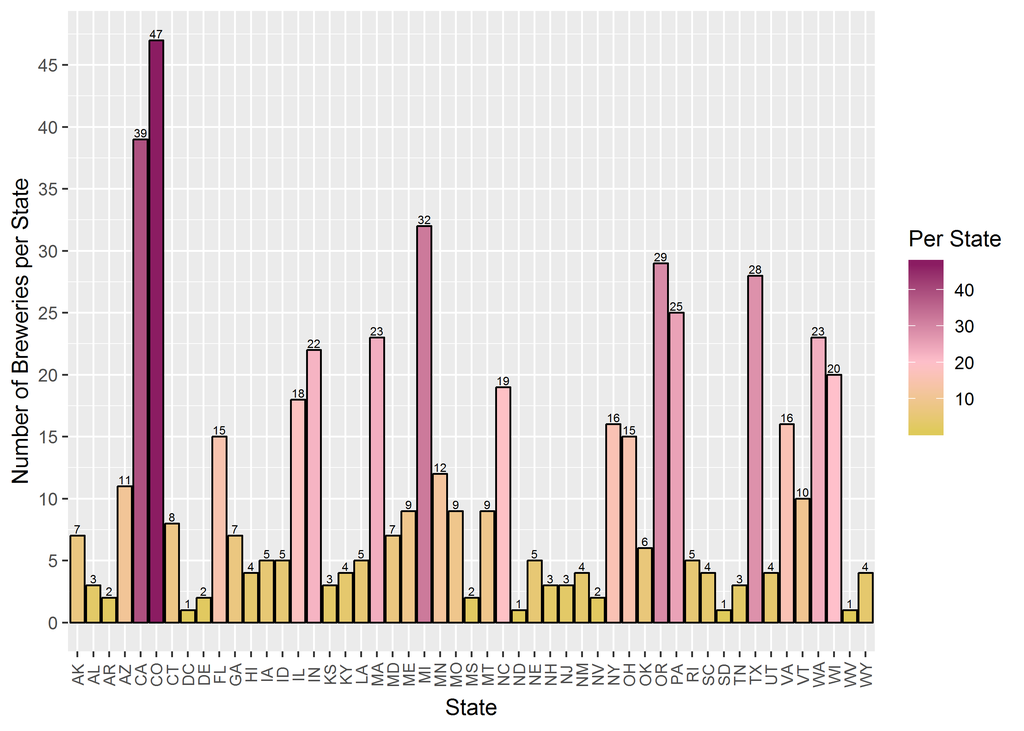

`Chart 1: Number of breweries by state`

### Question 2

##### The merge of the two datasets are validated with the first and last six (6) observations in Chart 2 and 3.

| Brew_ID | BreweryName | City | State | BeerName | Beer_ID | ABV | IBU | Style | Ounces |
| --- | --- | --- | --- | --- | --- | --- | --- | --- | --- |
| 1 | NorthGate Brewing | Minneapolis | MN | Pumpion | 2689 | 0.060 | 38 | Pumpkin Ale | 16 |
| 1 | NorthGate Brewing | Minneapolis | MN | Stronghold | 2688 | 0.060 | 25 | American Porter | 16 |
| 1 | NorthGate Brewing | Minneapolis | MN | Parapet ESB | 2687 | 0.056 | 47 | Extra Special / Strong Bitter (ESB) | 16 |
| 1 | NorthGate Brewing | Minneapolis | MN | Get Together | 2692 | 0.045 | 50 | American IPA | 16 |
| 1 | NorthGate Brewing | Minneapolis | MN | Maggie’s Leap | 2691 | 0.049 | 26 | Milk / Sweet Stout | 16 |
| 1 | NorthGate Brewing | Minneapolis | MN | Wall’s End | 2690 | 0.048 | 19 | English Brown Ale | 16 |

`Chart 2: First six rows of the merged dataset`

| Brew_ID | BreweryName | City | State | BeerName | Beer_ID | ABV | IBU | Style | Ounces |
| --- | --- | --- | --- | --- | --- | --- | --- | --- | --- |
| 556 | Ukiah Brewing Company | Ukiah | CA | Pilsner Ukiah | 98 | 0.055 | NA | German Pilsener | 12 |
| 557 | Butternuts Beer and Ale | Garrattsville | NY | Porkslap Pale Ale | 49 | 0.043 | NA | American Pale Ale (APA) | 12 |
| 557 | Butternuts Beer and Ale | Garrattsville | NY | Snapperhead IPA | 51 | 0.068 | NA | American IPA | 12 |
| 557 | Butternuts Beer and Ale | Garrattsville | NY | Moo Thunder Stout | 50 | 0.049 | NA | Milk / Sweet Stout | 12 |
| 557 | Butternuts Beer and Ale | Garrattsville | NY | Heinnieweisse Weissebier | 52 | 0.049 | NA | Hefeweizen | 12 |
| 558 | Sleeping Lady Brewing Company | Anchorage | AK | Urban Wilderness Pale Ale | 30 | 0.049 | NA | English Pale Ale | 12 |

`Chart 3: Last six rows of the merged dataset`

### Question 3

##### Chart 4 reports the number of NA’s in each column because the data analysis yielded incomplete values.

##### Of the 2410 beers contained in the dataset, 62 beers have missing ABV and 1005 have missing IBU values. There were 5 beers where the Style values were blank but not NA, although we will treat them as NA.

|  | NAs |
| --- | --- |
| Brew_ID | 0 |
| BreweryName | 0 |
| City | 0 |
| State | 0 |
| BeerName | 0 |
| Beer_ID | 0 |
| ABV | 62 |
| IBU | 1005 |
| Style | 5 |
| Ounces | 0 |

`Chart 4: Number of NA values per column`

### Question 4

##### Chart 5 and 6 plots the computed median alcohol content and international bitterness for each state.

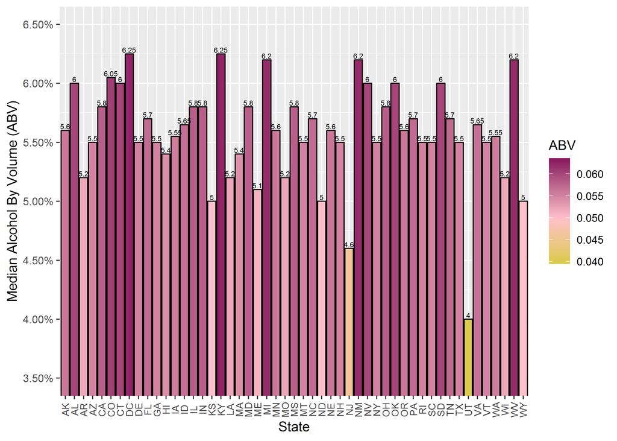

`Chart 5: Median ABV by State`

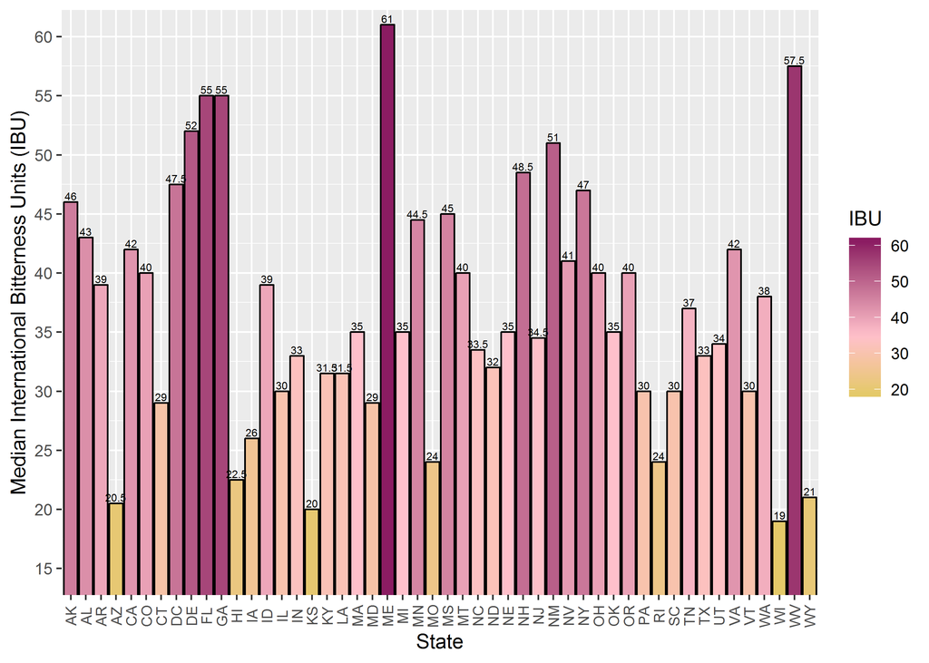

`Chart 6: Median IBU by State`

### Question 5

##### Chart 7 identifies Colorado as the state with the maximum ABV and Oregon as the state with the maximum IBU.

| Maximum ABV | MaximumIBU |
| --- | --- |
| CO | OR |

`Chart 7: State with the maximum ABV and maximum IBU`

### Question 6

##### Chart 8 summarizes the statistics for the ABV variable and shows that 50% of the beers have an ABV between 5% and 6.7% with the minimum and maximum being 0.1% and 12.8%.

| Min. | 0.0010000 |
| --- | --- |
| 1st Qu. | 0.0500000 |
| Median | 0.0560000 |
| Mean | 0.0597734 |
| 3rd Qu. | 0.0670000 |
| Max. | 0.1280000 |
| NA’s | 62.0000000 |

`Chart 8: ABV Summary`

### Question 7

##### Chart 9 reflects an apparent positive relationship between IBU and ABV values.

##### The black dotted line is the mean ABV at that value of IBU. The yellow shading is the standard deviation. While there is positive correlation between the ABV and IBU with a maximum ABV value peaking out around 10%, there are two outliers that warrant further examination for inclusion or exclusion depending on additional questions of interest. When answering those specific additional questions we would want to use something like Pearson’s r to gain an more precise answer.

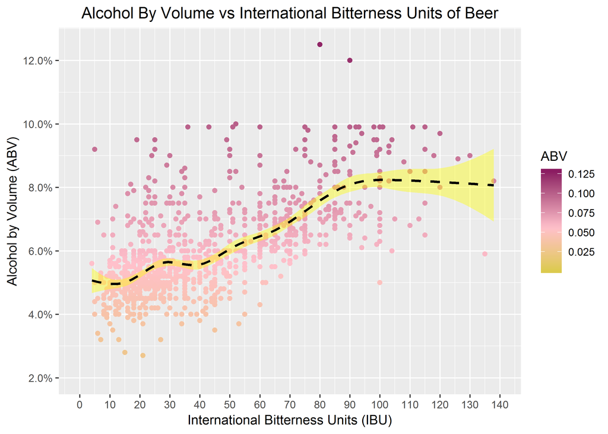

`Chart 9: Alcohol By Volume vs International Bitterness Units of beer`

## Conclusion

##### Based on the data above we have three recommendations. First we propose the events to be hosted in the states with the most number of breweries (Colorado [47], California [39], Michigan [32], Oregon [29], Texas [28]). As shown in Chart 1, this presents opportunities to expand services in those existing markets. The second recommendation is to host the events in the states that have the least amount of breweries (South Dakota [1], North Dakota [1], West Virginia [1]) which gives an opportunity to grow those markets. The final approach to the event selection is to host the events in the states that have the highest median IBU (Maine [61], West Virginia [57.5], Florida [55], Georgia [55], and Delaware [52]; see Chart 6.). There, we will bring beer that has similar style/ABV to the local beers but with a lower IBU (tastes less bitter) in order to gain market share.